# Exploration of HB 3 effects on school district revenue

In this analysis, I look for any possible relationships between certain school district characteristics and the change in per-student M&O revenue under CSHB 3 as passed by the House. First we import and join two Excel files: one with the school districts runs for HB 3 (NB: not the final runs as currently posted on the TEA and LBB web sites; I’ll import and bring in that data later) and another with an assortment of district characteristics gathered by TEA.

```r
library(ggplot2)
library(tidyverse)
library(readxl)
hb3 <- read_excel("hb3_4-5-19.xlsx", sheet = "HB3 FY 2020")
district <- read_excel("district.xls")
dfull <- inner_join(district, hb3, by = c("DISTRICT" = "District Number"))
```

First community type:

```r
dfull$COMMTYPE <- as.factor(dfull$COMMTYPE)
summary(dfull$COMMTYPE)
```

```
##                      Charters              Independent Town
##                           167                            68
##                Major Suburban                   Major Urban
##                            79                            11
## Non-metropolitan Fast Growing       Non-metropolitan Stable
##                            28                           173
##            Other Central City   Other Central City Suburban
##                            38                           165
##                         Rural
##                           460
```

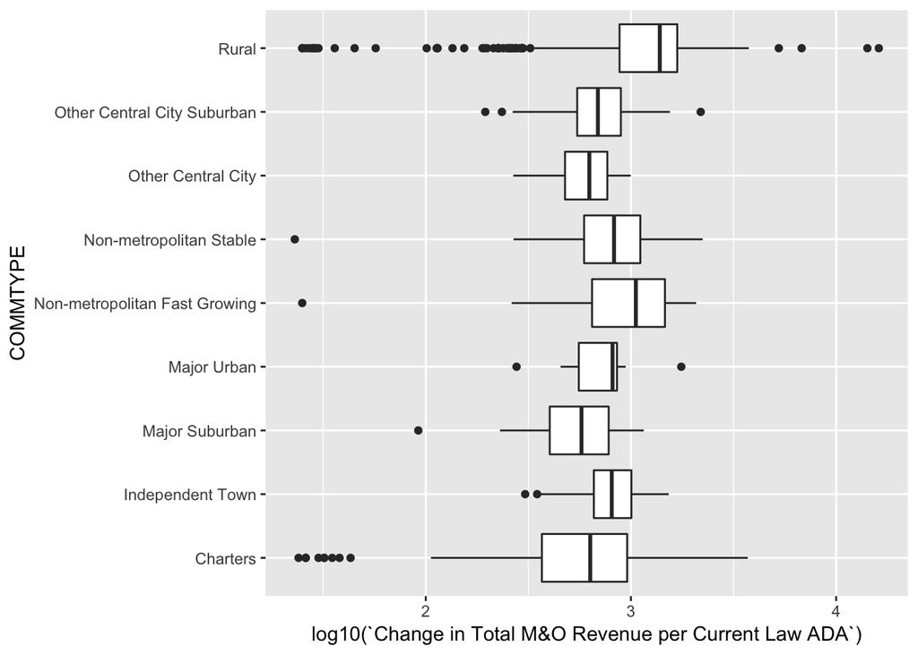

```r
ggplot(data = dfull, aes(x = COMMTYPE, y = log10(`Change in Total M&O Revenue per Current Law ADA`))) + geom_boxplot() + coord_flip()
```

It appears that rural and non-metropolitan fast-growing districts see a bigger bump in revenue than other kinds of districts. Note the variety of sample sizes among groups, however. Another way to see that is with a violin plot that includes jittered data points. This shows a bit more clearly the difference in group sizes.

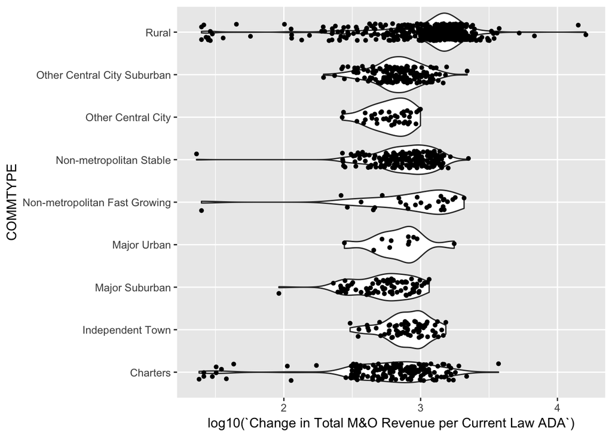

```r
ggplot(data = dfull, aes(x = COMMTYPE, y = log10(`Change in Total M&O Revenue per Current Law ADA`))) + geom_violin() + coord_flip() + geom_jitter(shape=16, position=position_jitter(0.2))
```

We see visually from the violin plot that for instance there are only 11 “major urban” districts, and many (almost 500) rural districts. What is the distribution of district sizes?

```r
dfull$DISTSIZE <- as.factor(dfull$DISTSIZE)
summary(dfull$DISTSIZE)
```

```
##   1,000 to 1,599   1,600 to 2,999 10,000 to 24,999 25,000 to 49,999
##              150              135               63               29
##   3,000 to 4,999   5,000 to 9,999  50,000 and over       500 to 999
##               88               77               20              236
##        Under 500
##              391
```

This gives us an idea of the distribution of sizes and of the types of districts. There are more small districts, most of which are rural.

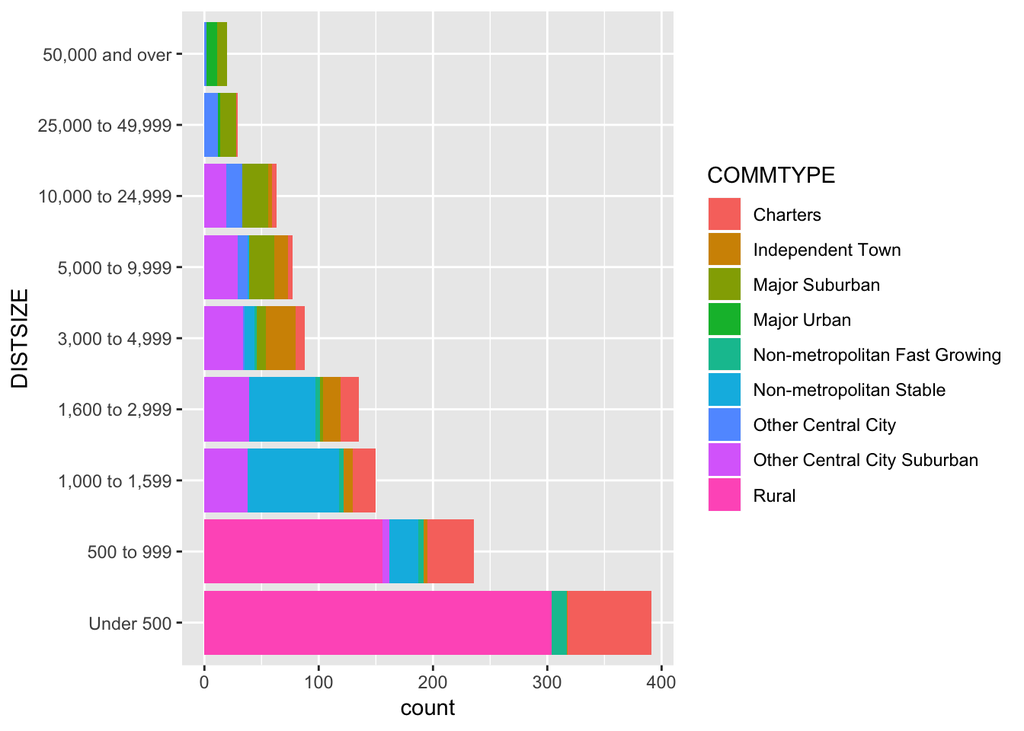

```r
ggplot(dfull) + geom_bar(aes(x = factor(DISTSIZE, c("Under 500","500 to 999","1,000 to 1,599","1,600 to 2,999","3,000 to 4,999","5,000 to 9,999","10,000 to 24,999","25,000 to 49,999","50,000 and over")), fill=COMMTYPE)) + coord_flip() + xlab("DISTSIZE")
```

It seems that smaller districts are seeing more M&O revenue per student, although there is a fairly wide variation among smaller districts.

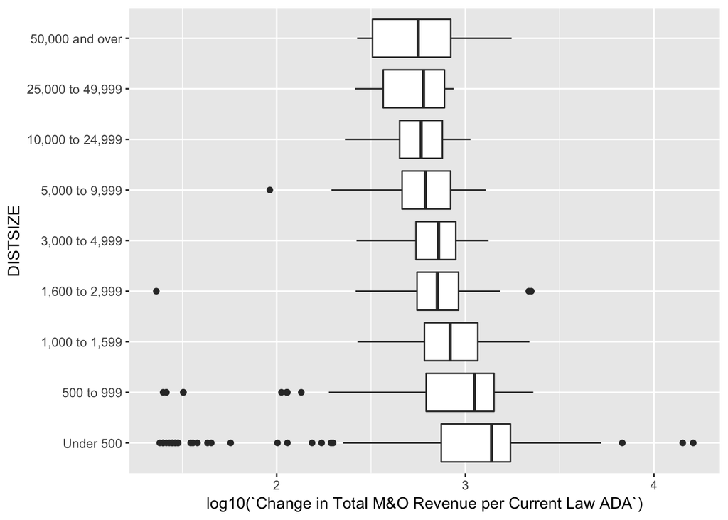

```r
ggplot(data = dfull, mapping = aes(x = factor(DISTSIZE, c("Under 500","500 to 999","1,000 to 1,599","1,600 to 2,999","3,000 to 4,999","5,000 to 9,999","10,000 to 24,999","25,000 to 49,999","50,000 and over")), y = log10(`Change in Total M&O Revenue per Current Law ADA`))) + geom_boxplot() + coord_flip() + xlab("DISTSIZE")
```

Then we look at tax rates, a categorical variable in the TEA data. It appears that districts with higher tax rates are seeing (a little) less of a bump in M&O revenue. As for the property wealth graph, it seems to suggest there is less variation in M&O change among lower-wealth districts than higher-wealth ones.

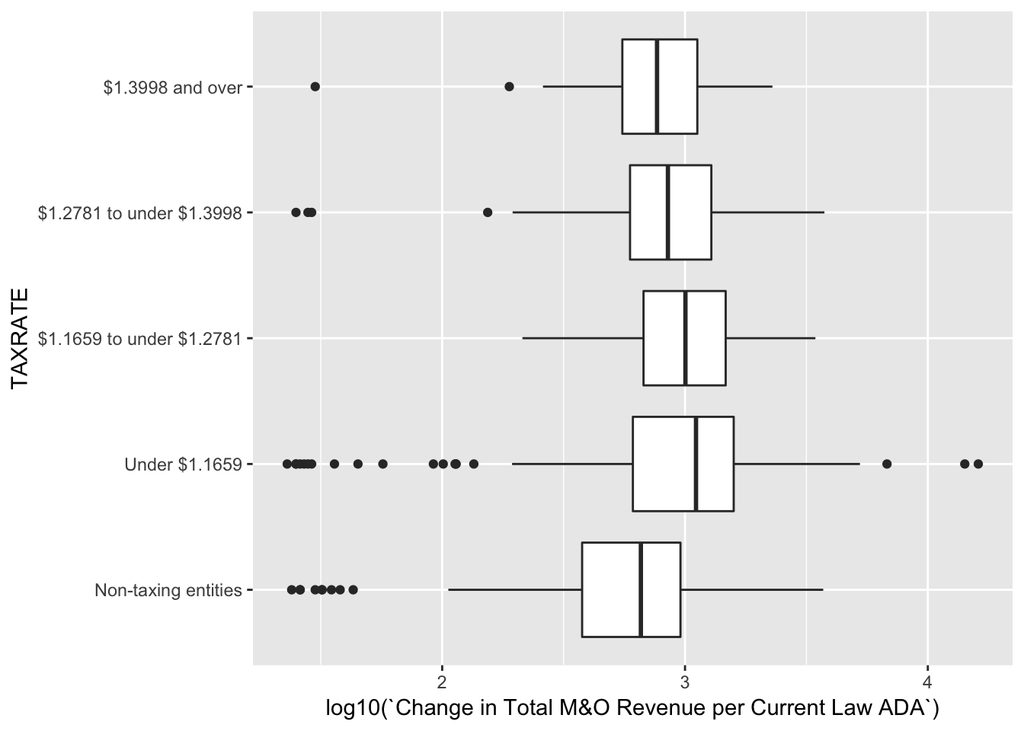

```r
ggplot(data = dfull, aes(x = factor(TAXRATE,c("Non-taxing entities","Under $1.1659","$1.1659 to under $1.2781","$1.2781 to under $1.3998","$1.3998 and over")), y = log10(`Change in Total M&O Revenue per Current Law ADA`))) + geom_boxplot() + coord_flip() + xlab("TAXRATE")
```

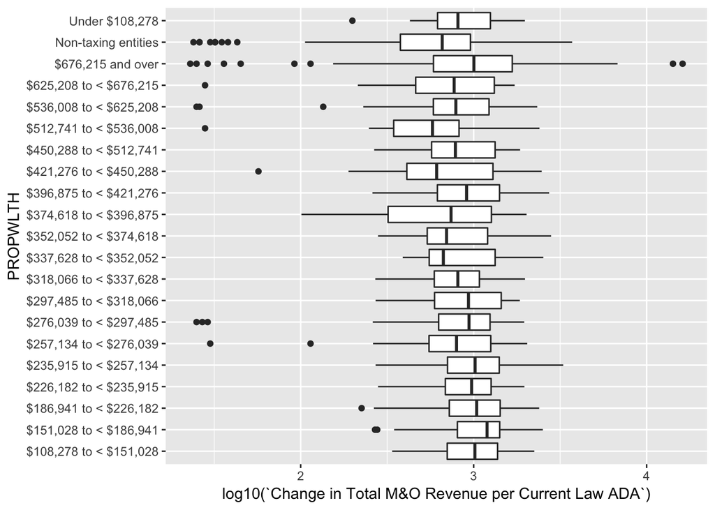

```r
ggplot(data = dfull, aes(x = PROPWLTH, y = log10(`Change in Total M&O Revenue per Current Law ADA`))) + geom_boxplot() + coord_flip()
```

Next some scatterplots of correlated variables. First variable DPFVTOTK, or TAXABLE VALUE PER PUPIL (2014 TAX YEAR). Not terribly conclusive; a negative correlation but varies some in the graph.

```r
dfull$DPFVTOTK <- as.numeric(dfull$DPFVTOTK)
cor(x = log10(dfull$DPFVTOTK), y = log10(dfull$`Change in Total M&O Revenue`), use="complete.obs")
```

```
## [1] -0.2813798
```

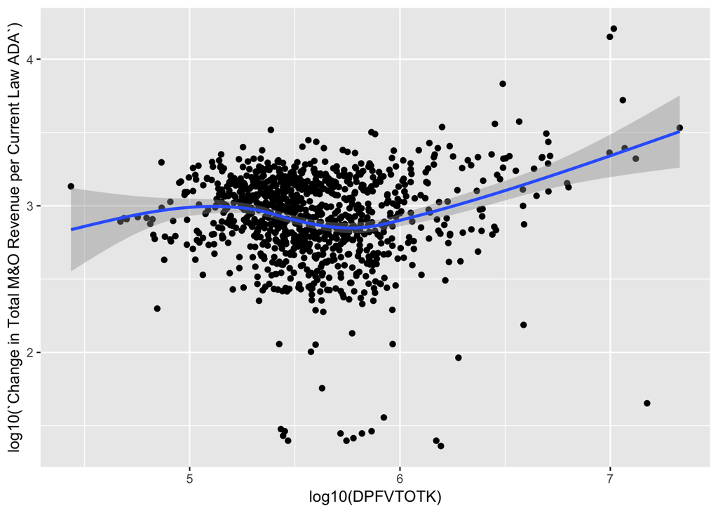

```r
ggplot(dfull, aes(x = log10(DPFVTOTK), y = log10(`Change in Total M&O Revenue per Current Law ADA`))) + geom_point() + geom_smooth()
```

Next is DPFRAALLK, TOTAL ACTUAL REVENUE PER PUPIL. Similarly inconclusive.

```r
dfull$DPFRAALLK <- as.numeric(dfull$DPFRAALLK)
```

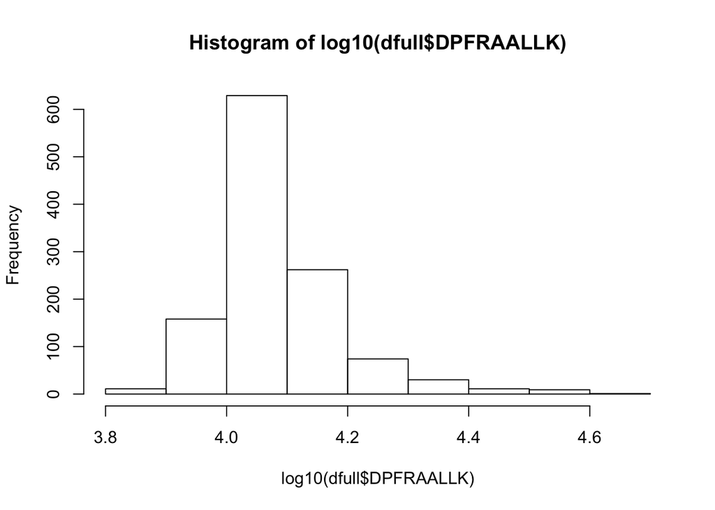

```r
hist(log10(dfull$DPFRAALLK))
```

```r
cor(x = log10(dfull$DPFRAALLK), y = log10(dfull$`Change in Total M&O Revenue`), use="complete.obs")
```

```
## [1] -0.3605958
```

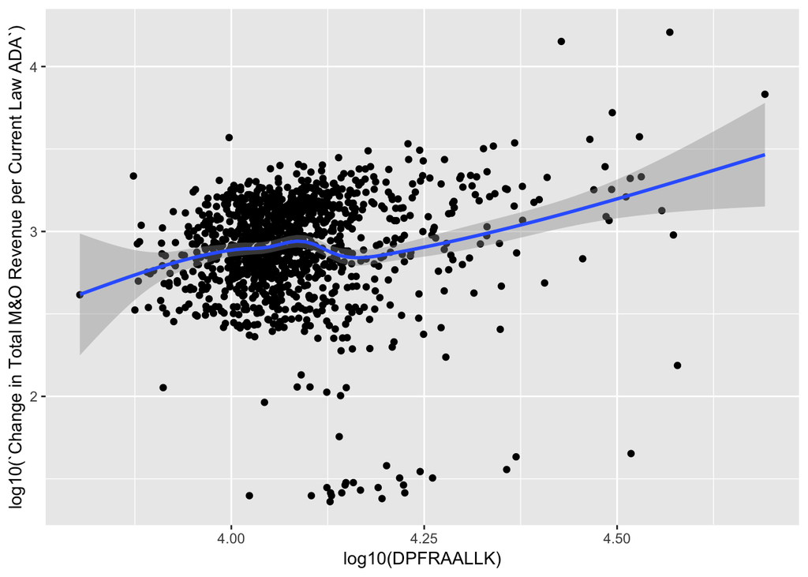

```r
ggplot(dfull, aes(x = log10(DPFRAALLK), y = log10(`Change in Total M&O Revenue per Current Law ADA`))) + geom_point() + geom_smooth()
```

Finally, DPFRAALLT, TOTAL ACTUAL REVENUE (2015-16). A fairly close correlation, where districts with high total revenue see a bigger rise in total M&O revenue post-HB 3.

```r
dfull$DPFRAALLT <- as.numeric(dfull$DPFRAALLT)
cor(x = log10(dfull$DPFRAALLT), y = log10(dfull$`Change in Total M&O Revenue`), use="complete.obs")
```

```
## [1] 0.8577973
```

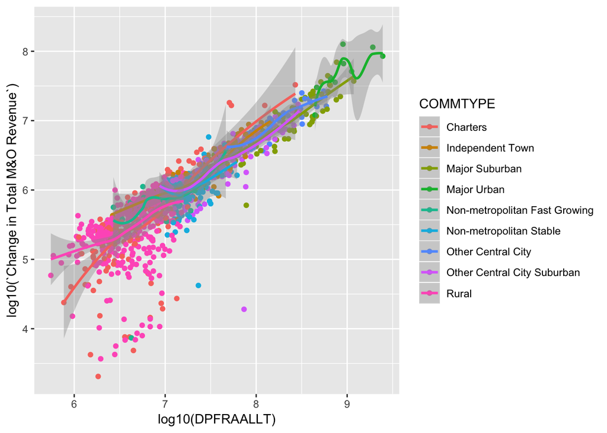

```r
ggplot(dfull, aes(x = log10(DPFRAALLT), y = log10(`Change in Total M&O Revenue`), color=COMMTYPE)) + geom_point() + geom_smooth()
```

You can also do maps, using TEA’s school district shapefiles obtained from their open data portal.

```r
library(sf)
```

```r
library(mapview)
cd <- st_read('Current_Districts/Current_Districts.shp', stringsAsFactors = FALSE)
dfullcopy <- inner_join(dfull, cd, by = c("DISTRICT" = "DISTRICT_C"))
```

```r
ggplot(data = dfullcopy) + geom_sf(aes(fill=log10(`Change in Total M&O Revenue per Current Law ADA`))) + scale_fill_viridis_c(alpha = .4)
```

[output not shown]

```r
ggplot(data = dfullcopy) + geom_sf(aes(fill=log10(`Change in Total M&O Revenue`))) + scale_fill_viridis_c(alpha = .4)
```

[output not shown]

Calculate the difference in recapture pre- and post-HB3. (Positive difference = district pays less in recapture.)

```r
dfullcopy$recapdiff <- dfullcopy$`Current Law Recapture` - dfullcopy$`HB 3 Recapture`
dfullcopy$recapdiff_ada <- dfullcopy$recapdiff / dfullcopy$`Current Law ADA`
```

…and map it, leaving out Kenedy County with its big recapture change, and also leaving out districts with no change in recapture.

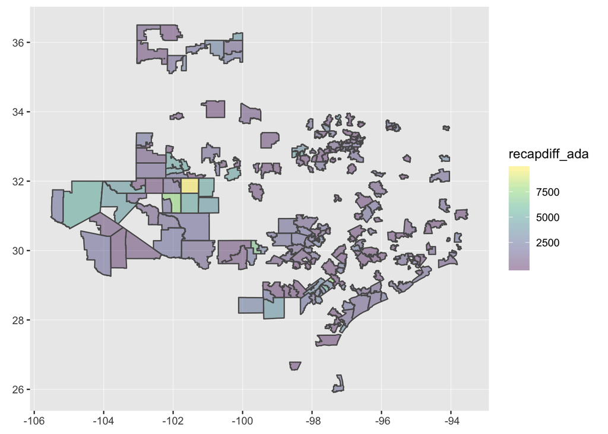

```r
dfullcopy %>% filter(recapdiff_ada>0) %>% filter(recapdiff_ada<10000) %>% ggplot() + geom_sf(aes(fill=recapdiff_ada)) + scale_fill_viridis_c(alpha = .4)
```

Alternatively, you can create this same map as a zoomable, dynamic leaflet web page with rollovers for school district info.

```r
dfullcopysf <- st_sf(dfullcopy)
map_recapdiff_ada <- dfullcopysf %>% filter(recapdiff_ada>0) %>% filter(recapdiff_ada<10000) %>% mapview(zcol="recapdiff_ada")
mapshot(map_recapdiff_ada, url = paste0(getwd(), "/docs/map_recapdiff_ada.html"))
```